## Survey Design for the 2016 Ohio Reservoir Methane Emission Study

## Introduction

Dr. Beaulieu is investigating the landscape and geomorphic factors that control methane (CH4) emission rates from reservoirs. Methane, a potent greenhouse gas, is produced via biological activity in the sediments at the bottom of lakes and reservoirs. The overall goal of the research program is to produce an estimate of the magnitude of CH4 emissions from reservoirs in the United States.

In the next phase of the research program, Dr. Beaulieu plans to use field surveys to identify the landscape and geomorphic factors that control CH4 emission rates from reservoirs within the state of Ohio. Ohio was chosen based on proximity to the EPA’s research facility in Cincinnati and the east to west agriculture/forest land-use gradient in the state.

There are three primary landscape and geomorphic factors that we hypothesize will control CH4 emission rates from reservoirs in the state. The following are our predictions, listed in order of decreasing effect size:

- CH4 emission rates will be positively correlated with the proportion of agricultural land use in the watershed.
- CH4 emission rates will be negatively related to maximum reservoir depth.
- CH4 emission rates will be positively correlated with the Relative Drainage Area (RDA, ratio of watershed area to reservoir surface area).

The following is an R session demonstrating different approaches for designing the survey.

## Exploration of the candidate sampling sites

The pool of potential reservoirs was derived from the list of Ohio reservoirs contained in the US Army Corps of Engineers National Inventory of Dams. This listed included 85 dams located on 81 separate reservoirs. Watershed size and land use was calculated for each reservoir using the USGS National Hydrography Dataset and the National Land Cover Data Set. Max reservoir depth was determined from bathymetric maps derived from various sources.

To inspect the data in R, first load the necessary libraries

```r
# The suppressWarnings suppresses trivial warnings and makes cleaner output.
suppressWarnings(library(readxl))  # For reading Excel filed
suppressWarnings(library(ggplot2)) # For plotting
suppressWarnings(library(dplyr, quietly = TRUE))   # For data manipulation
```

Read and inspect data

```r
# SET WORKING DIRECTORY.  MUST CHANGE FOR EACH USER
setwd("\\\\Aa.ad.epa.gov/ord/CIN/Users/main/F-K/JBEAULIE/Net MyDocuments/Documents/research/EPA/East Fork Reservoir/ACE/multiResSurvey/ohio")

ohioRes <- read_excel("inputData/ohioReservoirGeomorphology12.17.15.xlsx")
str(ohioRes)
```

```
## Classes 'tbl_df', 'tbl' and 'data.frame':    85 obs. of  27 variables:
##  $ Reservoir_ID                : num  9 44 77 76 16 32 14 75 79 47 ...
##  $ Lake_Name                   : chr  "Burr Oak Reservoir" "Lake Rupert" "Tappan Lake" "Senecaville Lake" ...
##  $ Dam                         : chr  "TOM JENKINS DAM" "LAKE RUPERT DAM" "TAPPAN DAM" "SENECAVILLE DAM" ...
##  $ Dam_Former_Name             : chr  "BURR OAK LAKE" "WELLSTON RESERVOIR" "TAPPAN LAKE" "SENECAVILLE LAKE" ...
##  $ State                       : chr  "OH" "OH" "OH" "OH" ...
##  $ Main_Dam                    : chr  "Yes" "Yes" "Yes" "Yes" ...
##  $ Reservoir_Polygon_YN        : chr  "Yes" "Yes" "Yes" "Yes" ...
##  $ Issue_Type                  : chr  NA NA "Constricted" "Constricted" ...
##  $ Res_Perimeter_m             : num  27004 14653 57427 70402 871 ...
##  $ Res_Fetch_m                 : num  1591 2490 4195 6829 369 ...
##  $ Reservoir_Area_m2           : num  2557169 1303103 8646808 14065779 29745 ...
##  $ Watershed_Area_m2           : num  8.56e+07 5.72e+07 1.84e+08 3.06e+08 1.09e+06 ...
##  $ Overlap_Watershed_YN        : chr  "Yes" "No" "Yes" "Yes" ...
##  $ Percent_OpenWater           : num  0.0274 0.0227 0.0486 0.0476 0.0643 ...
##  $ Percent_Urban               : num  0.0634 0.0542 0.0619 0.0646 0.0173 ...
##  $ Percent_Barren              : num  0.000189 0.000204 0.00685 0.00382 0.051895 ...
##  $ Percent_Forest              : num  0.832 0.759 0.693 0.69 0.676 ...
##  $ Percent_Shrub_Scrub         : num  0.00522 0.002516 0.000903 0.00104 0.00659 ...
##  $ Percent_Grassland_Herbaceous: num  0.0055 0.0191 0.0206 0.0137 0.0478 ...
##  $ Percent_Pasture_Hay         : num  0.0579 0.1076 0.1208 0.1087 0.07 ...
##  $ Percent_Culitvated_Crops    : num  0.00873 0.03311 0.04406 0.06926 0.0659 ...
##  $ Percent_Wetlands            : num  0.000116 0.001101 0.002895 0.000904 0 ...
##  $ Max_Depth_Ft                : num  NA NA NA NA NA NA NA NA NA NA ...
##  $ Max_Contour_Ft              : chr  "35-40" "24-27" "27-30" "21-24" ...
##  $ Contour_Interval_Ft         : num  5 3 3 3 NA 3 5 5 3 5 ...
##  $ Last_Surveyed               : num  2009 2006 1998 1999 NA ...
##  $ Contour/Depth_Link          : chr  "http://wildlife.ohiodnr.gov/Portals/wildlife/Maps/Lake%20Maps/PDFs/burroaklake2.pdf" "http://wildlife.ohiodnr.gov/Portals/wildlife/Maps/Lake%20Maps/PDFs/lakerupert2.pdf" "http://wildlife.ohiodnr.gov/Portals/wildlife/Maps/Lake%20Maps/PDFs/tappanlake2.pdf" "ht…
```

This next bit of code estimates max depth from the reported deepest contour lines

```r
ohioRes <- mutate(ohioRes,
                  Min_Contour_Ft = as.numeric(gsub("-.*$", "", Max_Contour_Ft)),  # extract prior to "-"
                  Max_Contour_Ft = as.numeric(gsub(".*-", "", Max_Contour_Ft)), # extract after"-"
                  Max_Depth_Ft = ifelse(is.na(Max_Depth_Ft),
                                        (Min_Contour_Ft + (Contour_Interval_Ft/2)),
                                        Max_Depth_Ft))
```

Data set contains some reservoirs not appropriate for this analysis. Pull out non-main dam, industrial reservoirs, and other troublesome reservoirs. This narrows the pool to 57 reservoirs.

```r
ohioResC <- filter(ohioRes, !grepl("Riverine|Not main dam.|Offstream|Connected|Industrial", Issue_Type))
length(unique(ohioResC$Lake_Name))  # 57 reservoirs
```

```
## [1] 57
```

Look at the distribution of watershed and reservoir properties. Note that reservoir area and the relative drainage area (RDA, ratio of the watershed to reservoir area) are log normally distributed.

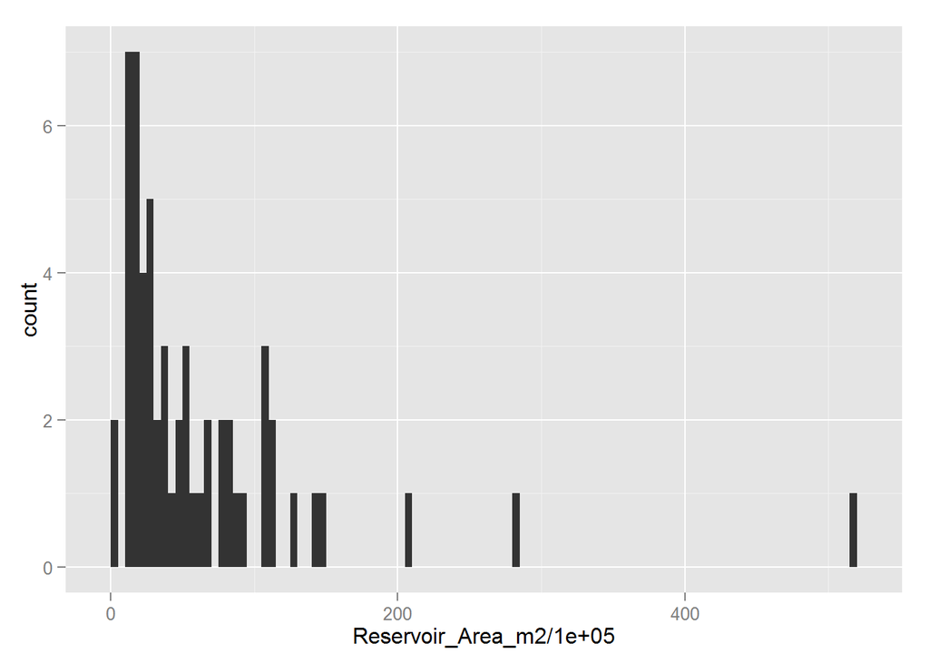

```r
# Reservoir area
ggplot(ohioResC, aes(x=Reservoir_Area_m2/100000)) + geom_histogram(binwidth=5)
```

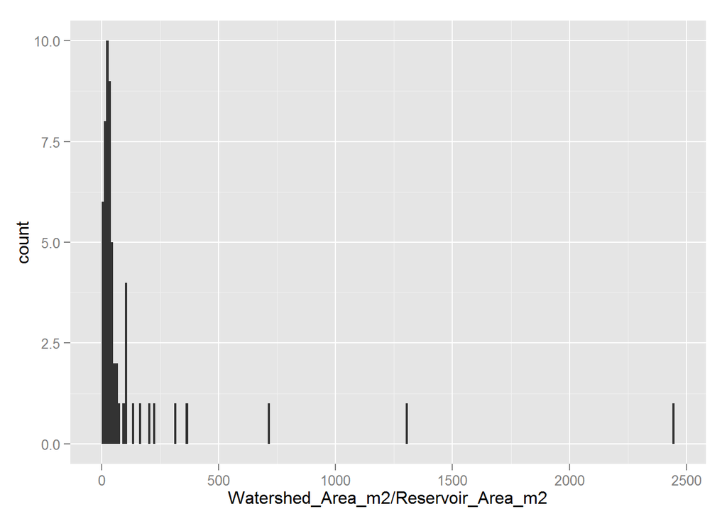

```r
# Relative drainage area
ggplot(ohioResC, aes(x=Watershed_Area_m2/Reservoir_Area_m2)) + geom_histogram(binwidth=10)
```

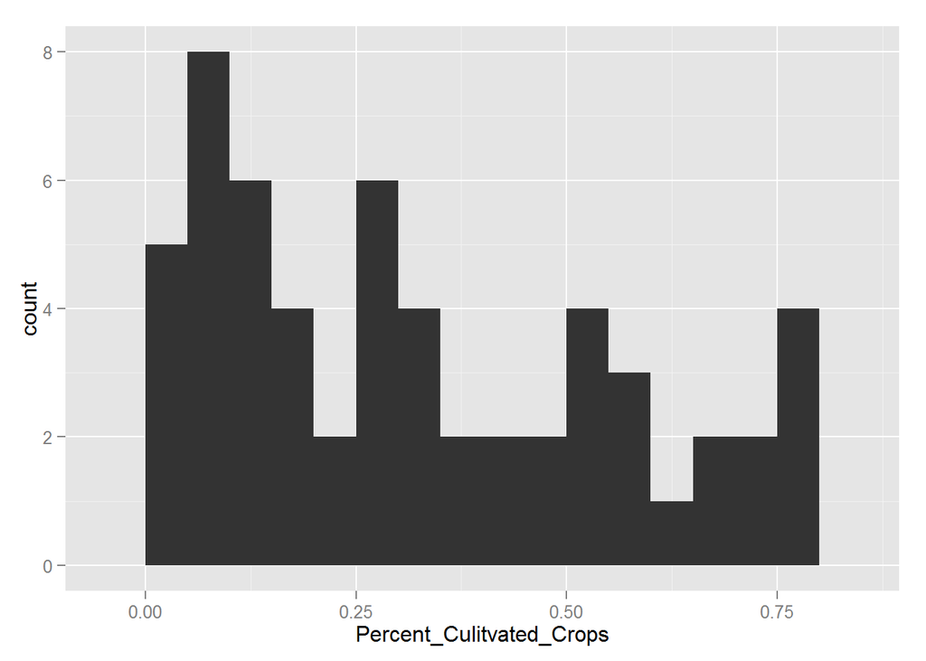

```r
# Agricultural land use
ggplot(ohioResC, aes(Percent_Culitvated_Crops)) + geom_histogram(binwidth=0.05)
```

## Exploration of survey designs

**Survey Design 1:** One approach to addressing the hypothesis/predictions would be to employ a survey design that employs two levels (i.e., high, low) of each of the three factors (i.e., agricultural land use, reservoir depth, RDA). This would be analogous to a 2<sup>3</sup> factorial experimental design containing 8 unique experimental treatments. To ensure a reasonably strong treatment, the ‘high’ and ‘low’ levels of each factor would be defined as values greater than the 70th percentile and less than the 30th percentile. There are a few problems with this approach, however. The first issue is that our pool of 57 reservoirs does not contain reservoirs in all 8 treatment combinations. We could perhaps address this by weakening our criteria for ‘high’ and ‘low’ treatments (by adopting a 60th and 40th quantile criteria for example), but this comes at the risk of weakening the treatment effect below our detection limit. Another issue is that this categorical approach provides no information on CH4 emission rates at intermediate levels of the three factors, which limits our ability to extrapolate our results to other systems.

The following code defines the treatment categories.

```r
ohioResC <- mutate(ohioResC,
                   Percent_Agg_Ag = Percent_Pasture_Hay + Percent_Culitvated_Crops, # aggregate agriculture
                   rda = Watershed_Area_m2/Reservoir_Area_m2,  # Relative Drainage Area (RDA)

                   luQuantBin = ifelse(Percent_Agg_Ag > quantile(Percent_Agg_Ag, 0.7), # top 30%
                                       "high",
                                 ifelse(Percent_Agg_Ag < quantile(Percent_Agg_Ag, 0.3),  # low 30%
                                        "low", "mid")),

                   depthQuantBin = ifelse(Max_Depth_Ft > quantile(Max_Depth_Ft, 0.7, na.rm=T), # top 30%
                                       "high",
                                 ifelse(Max_Depth_Ft < quantile(Max_Depth_Ft, 0.3, na.rm=T),# low 30%
                                        "low", "mid")),

                   rdaQuanBin = ifelse(rda > quantile(rda, 0.7, na.rm=T),  # top 30%
                                       "high",
                                 ifelse(rda < quantile(rda, 0.3, na.rm=T),  # low 30%
                                        "low", "mid")))

# Table to see if this pool of sites can populate a 3-factor by two level experimental design
with(ohioResC, table(luQuantBin, depthQuantBin, rdaQuanBin))  # experimental design not fully populated
```

```
## , , rdaQuanBin = high
##
##           depthQuantBin
## luQuantBin high low mid
##       high    2   0   7
##       low     0   1   1
##       mid     1   1   4
##
## , , rdaQuanBin = low
##
##           depthQuantBin
## luQuantBin high low mid
##       high    0   3   0
##       low     0   2   4
##       mid     2   1   4
##
## , , rdaQuanBin = mid
##
##           depthQuantBin
## luQuantBin high low mid
##       high    2   1   2
##       low     1   1   6
##       mid     4   1   4
```

**Survey Design 2:** As above, but exclude the RDA factor, which we expect to be the weakest of the three factors. This survey design would employ two levels (i.e., high, low) of each of two factors (i.e., agricultural land use, reservoir depth). To minimize the possibility of variation in RDA confounding the main treatment effects, we should probably exclude any reservoirs with extreme RDA values from the pool of candidate sites. The RDA values have a log normal distribution, therefore it might be best to exclude the few very high values (i.e., > 500). The pool of candidate sites can support this survey design. We have sufficient sites to include 3-4 replicates in all treatment categories except for the high-depth x low-agriculture treatment where we only have one site. While this approach may work, it provides no information on CH4 emission rates at intermediate levels of the two factors, thereby limiting our ability to extrapolate our results to other systems.

```r
# Need to assess a 2 factor by 2-level experimental design.  Remove sites with extreme RDA values
# and recalculate quantiles
ohioResC2 <- filter(ohioResC, rda < 500)  %>%  # exclude extreme RDA values
  mutate(luQuantBin = ifelse(Percent_Agg_Ag > quantile(Percent_Agg_Ag, 0.7), # top 30%
                             "high",
                             ifelse(Percent_Agg_Ag < quantile(Percent_Agg_Ag, 0.3),  # low 30%
                                    "low", "mid")),

         depthQuantBin = ifelse(Max_Depth_Ft > quantile(Max_Depth_Ft, 0.7, na.rm=T), # top 30%
                                "high",
                                ifelse(Max_Depth_Ft < quantile(Max_Depth_Ft, 0.3, na.rm=T),# low 30%
                                       "low", "mid")))

# Table to see if this pool of sites can populate a 2-factor by two level experimental design
with(ohioResC2, table(luQuantBin, depthQuantBin))  # experimental design is fully populated
```

```
##           depthQuantBin
## luQuantBin high low mid
##       high    4   4   8
##       low     1   3  11
##       mid     6   3  12
```

*Survey Design 3:* This survey design is an extension of Survey Design 2 where we utilize additional levels of the two factors (i.e., agricultural land use, reservoir depth) to ensure that we include sites across the full range of reservoir depth and agricultural land-use. For example, we could define four levels of each category (level 1 = 0-25th percentile, level 2 = 26-50th percentile, level 3 = 51-75th percentile, level 4 = 76-100th percentile). This would be a 4<sup>2</sup> experimental design consisting of 16 unique treatment combinations. My resources and pool of candidate sites are sufficient to include replication in some, but not all of the treatment combinations. Although this survey is designed based on categories, I think it would be best to treat the main factors as continuous variables in the statistical analysis.

```r
# Extend the experimental design to inlcude multiple levels of the two factors.
ohioResC3 <- mutate(ohioResC2,
                    luQuantBin = cut(Percent_Agg_Ag,
                                     breaks = quantile(Percent_Agg_Ag),
                                     include.lowest = TRUE,
                                     labels = 1:4),
                    depthQuantBin = cut(Max_Depth_Ft,
                                     breaks = quantile(Max_Depth_Ft, na.rm = TRUE),
                                     include.lowest = TRUE,
                                     labels = 1:4))

# Table to see if this pool of sites can populate a 2-factor by four level experimental design
with(ohioResC3, table(luQuantBin, depthQuantBin))  # experimental design is fully populated with potential for replication
```

```
##           depthQuantBin
## luQuantBin 1 2 3 4
##          1 5 2 5 1
##          2 5 4 1 3
##          3 5 1 1 5
##          4 4 4 4 2
```

# Misc code: Alternative approach to bin by range, rather than quantiles